# IF540_Kelas EL_00000054804_Christopher Darren_Week14

## TUGAS LAB IF540 MACHINE LEARNING

### WEEK 14 : EVALUATING TECHNIQUES

#### Semester Genap 2022/2023

```python
# Run this code when you restart the machine
# Fill in with YOUR name and NIM
import datetime
import uuid

myName = "Christopher Darren"
myNIM = "00000054804"
```

```python
myDate = datetime.datetime.now()
myDevice = str(uuid.uuid1())

print("Name: \t\t{}".format(myName))
print("NIM: \t\t{}".format(myNIM))
print("Start: \t\t{}".format(myDate))
print("Device ID: \t{}".format(myDevice))
```

```
Name: 		Christopher Darren
NIM: 		00000054804
Start: 		2023-05-29 19:30:03.625218
Device ID: 	8968fe1d-fe1c-11ed-a050-f02f74a116e8
```

### Hasil kerja

### CLASSIFICATION MODEL

##### 1. Before we proceed to build, let’s first see how both the data and the image we intend to analyze look. The following code will load the data for the image at index 10 and plot it :

```python
from sklearn import datasets, metrics
import matplotlib.pyplot as plt

%matplotlib inline
```

```python
digits = datasets.load_digits()
```

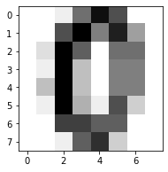

```python
plt.figure(figsize=(3,3))
plt.imshow(digits.images[10], cmap=plt.cm.gray_r)
```

#### 2. We can determine how the raw pixel data looks the flattened vector representation and the number (class label) , which represented by the image using the following code :

#### Actual Image :

```python
digits.images[10]
```

```
array([[ 0.,  0.,  1.,  9., 15., 11.,  0.,  0.],
       [ 0.,  0., 11., 16.,  8., 14.,  6.,  0.],
       [ 0.,  2., 16., 10.,  0.,  9.,  9.,  0.],
       [ 0.,  1., 16.,  4.,  0.,  8.,  8.,  0.],
       [ 0.,  4., 16.,  4.,  0.,  8.,  8.,  0.],
       [ 0.,  1., 16.,  5.,  1., 11.,  3.,  0.],
       [ 0.,  0., 12., 12., 10., 10.,  0.,  0.],
       [ 0.,  0.,  1., 10., 13.,  3.,  0.,  0.]])
```

#### Flattened Image :

```python
digits.data[10]
```

```
array([ 0.,  0.,  1.,  9., 15., 11.,  0.,  0.,  0.,  0., 11., 16.,  8.,
       14.,  6.,  0.,  0.,  2., 16., 10.,  0.,  9.,  9.,  0.,  0.,  1.,
       16.,  4.,  0.,  8.,  8.,  0.,  0.,  4., 16.,  4.,  0.,  8.,  8.,
        0.,  0.,  1., 16.,  5.,  1., 11.,  3.,  0.,  0.,  0., 12., 12.,
       10., 10.,  0.,  0.,  0.,  0.,  1., 10., 13.,  3.,  0.,  0.])
```

#### Image class label :

```python
digits.target[10]
```

```
0
```

```python
X_digits = digits.data
y_digits = digits.target

num_data_points = len(X_digits)
X_train = X_digits[:int(.7*num_data_points)]
y_train = y_digits[:int(.7*num_data_points)]
X_test = X_digits[:int(.7*num_data_points)]
y_test = y_digits[:int(.7*num_data_points)]
print(X_train.shape, X_test.shape)
```

```
(1257, 64) (1257, 64)
```

#### 4. The next step is specifying the model that we will be using and the hyperparameter values that we want to use. The values of hyperparameter do not depend on the underlying data and are usually set prior to model training and are fine tuned for extracting the best model.

```python
from sklearn import linear_model
logistic = linear_model.LogisticRegression()
logistic.fit(X_train, y_train)
```

```
LogisticRegression()
```

```python
print('Logistic Regression mean Accuracy : %f' %logistic.score(X_test, y_test))
```

```
Logistic Regression mean Accuracy : 1.000000
```

### EVALUATING THE CLUSTERING

#### 6. Let’s load the data using the following code

```python
#Using Wisconsin Breast Cancer dataset
import numpy as np
from sklearn.datasets import load_breast_cancer

#load data
data = load_breast_cancer()
X= data.data
y= data.target
print(X.shape, data.feature_names)
```

```
(569, 30) ['mean radius' 'mean texture' 'mean perimeter' 'mean area'
 'mean smoothness' 'mean compactness' 'mean concavity'
 'mean concave points' 'mean symmetry' 'mean fractal dimension'
 'radius error' 'texture error' 'perimeter error' 'area error'
 'smoothness error' 'compactness error' 'concavity error'
 'concave points error' 'symmetry error' 'fractal dimension error'
 'worst radius' 'worst texture' 'worst perimeter' 'worst area'
 'worst smoothness' 'worst compactness' 'worst concavity'
 'worst concave points' 'worst symmetry' 'worst fractal dimension']
```

#### Partitioning Based Clustering

#### 7. Import the KMeans :

```python
#Unsupervised learning-partitioning
from sklearn.cluster import KMeans

km = KMeans(n_clusters=2, random_state=2, n_init=10)
km.fit(X)

labels = km.labels_
centers=km.cluster_centers_
print(labels[:10])
```

```
[0 0 0 1 0 1 0 1 1 1]
```

#### 8. Because we dealing with 30 features and visualizing the centers on a 30-dimensional features space would be impossible to interpret or even perform. Hence, we will leverage PCA to reduce the input dimensions to two principal components and visualize the clusters on top of the same.

```python
from sklearn.decomposition import PCA

pca = PCA(n_components=2)
bc_pca = pca.fit_transform(X)
```

#### 9. The following code helps visualize the clusters on the reduced 2D feature space for the actual labels as well as the clustered output labels

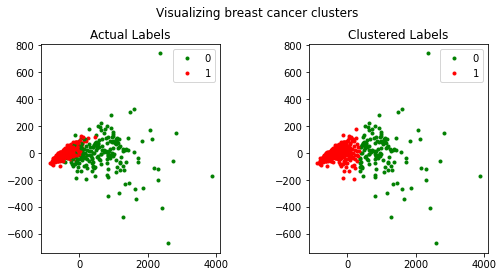

```python
fig, (ax1, ax2) = plt.subplots(1, 2, figsize=(8, 4) )
fig.suptitle('Visualizing breast cancer clusters')
fig.subplots_adjust(top=0.85, wspace =0.5)
ax1.set_title('Actual Labels')
ax2.set_title('Clustered Labels')

for i in range(len(y)):
    if y[i] == 0:
        c1 = ax1.scatter(bc_pca[i, 0], bc_pca[i, 1], c='g', marker='.')
    if y[i] == 1:
        c2 = ax1.scatter(bc_pca[i, 0], bc_pca[i,1], c='r', marker='.')

    if labels[i] == 0:
        c3 = ax2.scatter(bc_pca[i, 0], bc_pca[i, 1], c='g', marker='.')
    if labels[i] == 1:
        c4 = ax2.scatter(bc_pca[i, 0], bc_pca[i, 1], c='r', marker='.')

l1 = ax1.legend([c1, c2], ['0','1'])
l2 = ax2.legend([c3, c4], ['0','1'])
```

#### Hierarchical Clustering

#### 10. Using AgglomerativeClustering and Ward’s distance metric :

```python
#Unsupervised Learning - Hierachical

from scipy.cluster.hierarchy import dendrogram, linkage
import numpy as np
np.set_printoptions(suppress=True)

Z=linkage(X, 'ward')
print(Z)
```

```
[[  287.           336.             3.81596727     2.        ]
 [  106.           420.             4.11664267     2.        ]
 [   55.           251.             4.93361024     2.        ]
 ...
 [ 1130.          1132.          6196.07482529    86.        ]
 [ 1131.          1133.          8368.99225244   483.        ]
 [ 1134.          1135.         18371.10293626   569.        ]]
```

#### 11. Visualize these distance – based merges is to use a dendrogram :

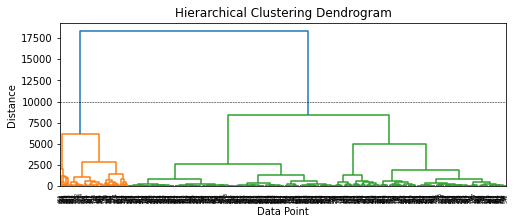

```python
plt.figure(figsize=(8,3))
plt.title('Hierarchical Clustering Dendrogram')
plt.xlabel('Data Point')
plt.ylabel('Distance')
dendrogram(Z)
plt.axhline(y=10000, c='k', ls='--', lw=0.5)
plt.show()
```

#### 12. Leverage this distance, we can get the cluster labels using following code :

```python
from scipy.cluster.hierarchy import fcluster
max_dist = 10000
hc_labels = fcluster(Z, max_dist, criterion='distance')
```

#### 13. Compare how the cluster outputs look based on the PCA reduced dimensions as compared to the original label distribution.

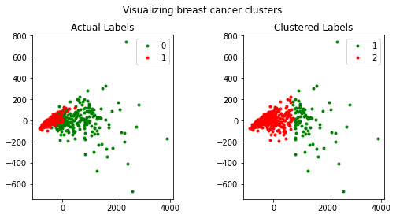

```python
fig, (ax1, ax2) = plt.subplots(1, 2, figsize=(8, 4) )
fig.suptitle('Visualizing breast cancer clusters')
fig.subplots_adjust(top=0.85, wspace =0.5)
ax1.set_title('Actual Labels')
ax2.set_title('Clustered Labels')

for i in range(len(y)):
    if y[i] == 0:
        c1 = ax1.scatter(bc_pca[i, 0], bc_pca[i, 1], c='g', marker='.')
    if y[i] == 1:
        c2 = ax1.scatter(bc_pca[i, 0], bc_pca[i,1], c='r', marker='.')

    if hc_labels[i] == 1:
        c3 = ax2.scatter(bc_pca[i, 0], bc_pca[i, 1], c='g', marker='.')
    if hc_labels[i] == 2:
        c4 = ax2.scatter(bc_pca[i, 0], bc_pca[i, 1], c='r', marker='.')

l1 = ax1.legend([c1, c2], ['0','1'])
l2 = ax2.legend([c3, c4], ['1','2'])
```

### MODEL EVALUATION

#### Evaluating Classification Models

#### 14. Prepare train and test datasets to build our classification models. We will be leveraging by X and y variables from before, which holds the data and labels for the breast cancer dataset observations

```python
from sklearn.model_selection import train_test_split

X_train, X_test, y_train, y_test = train_test_split(X, y, test_size=0.3, random_state=42)
print(X_train.shape, X_test.shape)
```

```
(398, 30) (171, 30)
```

#### Confusion Matrix

#### 15. Let’s build a logistic regression model on our breast cancer dataset and look at the confusion matrix for the model predictions on the test dataset.

```python
from sklearn import  linear_model

logistic = linear_model.LogisticRegression()
logistic.fit(X_train, y_train)
```

```
LogisticRegression()
```

```python
# confusion matrix
import model_evaluation_utils as meu

y_pred = logistic.predict(X_test)
meu.display_confusion_matrix(true_labels=y_test, predicted_labels=y_pred, classes=[0, 1])
```

```
          Predicted:
                   0    1
Actual: 0         59    4
        1          1  107
```

```python
possitive_class = 1
TP = 106
FP=4
TN=9
FN=2
```

#### Performance Metrics

#### 17. Accuracy : this is one of the most popular measures of classifier performance, it is defined as the overall accuracy or proportions of correct predictions of the model. The following code computes accuracy on our model predictions :

```python
fw_acc = round(meu.metrics.accuracy_score(y_true=y_test, y_pred=y_pred), 5)
mc_acc = round((TP + TN) / (TP + TN + FP +FN), 5)
print('Framework Accuracy:', fw_acc)
print('Manually Computed Accuracy:', mc_acc)
```

```
Framework Accuracy: 0.97076
Manually Computed Accuracy: 0.95041
```

#### 18. Precision : also known as positive value, is another metric that can be derived from the confusion matrix. It is defined as the number of predictions made that are actually correct or relevant out of all predictions based in the positive class. The following code computes precision on our model predictions :

```python
fw_prec = round(meu.metrics.precision_score(y_true=y_test, y_pred=y_pred), 5)
mc_prec = round((TP) / (TP + FP), 5)
print('Framework Precision:', fw_prec)
print('Manually Computed Accuracy:', mc_prec)
```

```
Framework Precision: 0.96396
Manually Computed Accuracy: 0.96364
```

#### 19. Recall : also known as sensitivity, is a measure of a model to identify the percentage of relevant data points. it is defined as the number of instance of the positive class that were correctly predicted. The following code computes recall on our model predictions :

```python
fw_rec = round(meu.metrics.recall_score(y_true=y_test, y_pred=y_pred), 5)
mc_rec = round((TP) / (TP + FN), 5)
print('Framework Recall:', fw_rec)
print('Manually Computed Accuracy:', mc_rec)
```

```
Framework Recall: 0.99074
Manually Computed Accuracy: 0.98148
```

#### 20. F1 – Score : there are some cases in which we want a balanced optimization of both precision and recall. F1 score is metric that is the harmonic mean of precision and recall and help us optimize a classifier for balanced precision and recall performance. Let’s compute the F1 score on the predictions made by our mode using the following code :

```python
fw_f1 = round(meu.metrics.f1_score(y_true=y_test, y_pred=y_pred), 5)
mc_f1 = round((2*mc_prec*mc_rec) / (mc_prec + mc_rec), 5)
print('Framework Recall:', fw_f1)
print('Manually Computed Accuracy:', mc_f1)
```

```
Framework Recall: 0.97717
Manually Computed Accuracy: 0.97248
```

#### 21. Receiver Operating Characteristic Curve (ROC Curve) : the curve can be created by plotting the fraction of true positive versus the fraction of false positive. It is applicable mostly for scoring classifiers. Scoring classifiers are the type of classifiers which will return a probability value or score for each class label, from which a class label can be deduced (based on maximum probability value). This curve can be plotted using the True Positive Rate (TPR) and False Positive Rate (FPR) of a classifier. TPR is known as sensitivity or recall. FPR is known as false alarms or (1 – specificity), determining the total number of incorrect positive predictions among all negative samples in the dataset.

#### The following code plots the ROC curve for our breast cancer logistic regression model leveraging the same function (model_evaluation_utils).

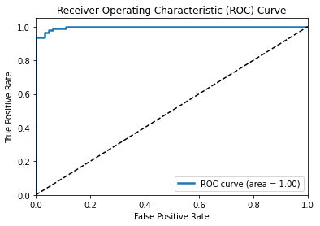

```python
meu.plot_model_roc_curve(clf=logistic, features=X_test, true_labels=y_test)
```

#### Evaluating Clustering Models

#### 22. To illustrate the evaluation metrics with a real world example, we will leverage the breast cancer dataset available in the variables X for the data y for the observation labels. We will also use the K means algorithm to fit two model on this data – one with two clusters and the second one with five clusters – and then evaluate their performance

```python
import os
os.environ['OMP_NUM_THREADS'] = '3'
```

```python
km2 = KMeans(n_clusters=2, random_state=42).fit(X)
km2_labels = km2.labels_

km5 = KMeans(n_clusters=5, random_state=42).fit(X)
km5_labels = km5.labels_
```

#### 23. These values of external validation are typically bounded between 0 and 1 and usually higher values are better. Let’s compute these metric on our K Means clustering model :

```python
km2_hcv = np.round(metrics.homogeneity_completeness_v_measure(y, km2_labels), 3)
km5_hcv = np.round(metrics.homogeneity_completeness_v_measure(y, km5_labels), 3)

print('Homogeneity, Completeness, V-measure metrics for num clusters=2: ', km2_hcv)
print('Homogeneity, Completeness, V-measure metrics for num clusters=5: ', km5_hcv)
```

```
Homogeneity, Completeness, V-measure metrics for num clusters=2:  [0.422 0.517 0.465]
Homogeneity, Completeness, V-measure metrics for num clusters=5:  [0.602 0.298 0.398]
```

#### 24. In the scikit-learn, we can compute the Silhouette coefficient using the silhouette_score function. The function also allows for different options for distance metrics.

```python
from sklearn import metrics

km2_silc = metrics.silhouette_score(X, km2_labels, metric='euclidean')
km5_silc = metrics.silhouette_score(X, km5_labels, metric='euclidean')

print('Silhouette Coefficient for num clusters=2: ', km2_silc)
print('Silhouette Coefficient for num clusters=2: ', km5_silc)
```

```
Silhouette Coefficient for num clusters=2:  0.6972646156059464
Silhouette Coefficient for num clusters=2:  0.5102292997907838
```

#### Evaluating Regression Model

#### Mean Square Error (MSE)

#### 25. Load the libraries

```python
from sklearn.datasets import make_regression
from sklearn.model_selection import cross_val_score
from sklearn.linear_model import LinearRegression
```

#### 26. Generate feature matrix, generate target vector

```python
feature, target = make_regression(n_samples=100,
                                 n_features=3,
                                 n_informative=3,
                                 n_targets=1,
                                 noise=1,
                                 coef=False,
                                 random_state=1)
```

#### 27. Create a linear regression object

```python
ols = LinearRegression()
```

#### 28. Cross validate the linear regression using (negative) MSE

```python
cross_val_score(ols, feature, target, scoring='neg_mean_squared_error')
```

```
array([-0.78986135, -0.80181655, -1.57407742, -0.42401745, -0.63949642])
```

#### R-Squared (R2)

#### 29. The function of R-squared in scikit-learn is using scoring = ‘r2’. This the following code :

```python
cross_val_score(ols, feature, target, scoring='r2')
```

```
array([0.99994298, 0.99991772, 0.99985451, 0.9999636 , 0.99991436])
```

## MODEL TUNING

#### Hyperparameter Tuning Strategies

#### 30. Let’s first split our breast cancer dataset variables X and y into train and test datasets and build an SVM model with default parameters. Then we’ll evaluate its performance on the test dataset by leveraging our model_evaluation_utils module.

```python
from sklearn.model_selection import train_test_split
from sklearn.svm import SVC

# prepare datasets
X_train, X_test, y_train, y_test = train_test_split(X, y, test_size=0.3, random_state=42)

# build default SVM model
def_svc = SVC(random_state=42)
def_svc.fit(X_train, y_train)

# predict and evaluate performance
def_y_pred = def_svc.predict(X_test)
print('Default Model Stats:')
meu.display_model_performance_metrics(true_labels=y_test, predicted_labels=def_y_pred, classes=[0, 1])
```

```
Default Model Stats:
Model Performance metrics:
------------------------------
Accuracy: 0.9357
Precision: 0.9416
Recall: 0.9357
F1 Score: 0.9342

Model Classification report:
------------------------------
              precision    recall  f1-score   support

           0       1.00      0.83      0.90        63
           1       0.91      1.00      0.95       108

    accuracy                           0.94       171
   macro avg       0.95      0.91      0.93       171
weighted avg       0.94      0.94      0.93       171


Prediction Confusion Matrix:
------------------------------
          Predicted:
                   0    1
Actual: 0         52   11
        1          0  108
```

#### 31. Setting the parameter grid, which is C (deals with the margin parameter in SVM), the kernel function (used for transforming data into a higher dimensional feature space), and gamma (determines the influence a single training data point has).

```python
from sklearn.model_selection import GridSearchCV

# setting the parameter grid
grid_parameters = {'kernel':['linear','rbf'],
                   'gamma':[1e-3, 1e-4],
                   'C': [1, 10, 50, 100]}

# perform hyperparamete tuning
print("# Tuning hyper-parameters for accuracy\n")
clf = GridSearchCV(SVC(random_state=42), grid_parameters, cv=5, scoring='accuracy')
clf.fit(X_train, y_train)

# view accuracy scores for all the models
print("Grid scores for all the models based on CV:\n")
means = clf.cv_results_['mean_test_score']
stds = clf.cv_results_['std_test_score']
for mean, std, params in zip(means, stds, clf.cv_results_['params']):
    print("%0.5f (+/-%0.05f) for %r" % (mean, std * 2, params))
# check out best model performance
print("\nBest parameters set found on development set:", clf.best_params_)
print("Best model validation accuracy:", clf.best_score_)
```

```
# Tuning hyper-parameters for accuracy

Grid scores for all the models based on CV:

0.95218 (+/-0.06256) for {'C': 1, 'gamma': 0.001, 'kernel': 'linear'}
0.91193 (+/-0.04607) for {'C': 1, 'gamma': 0.001, 'kernel': 'rbf'}
0.95218 (+/-0.06256) for {'C': 1, 'gamma': 0.0001, 'kernel': 'linear'}
0.92459 (+/-0.02287) for {'C': 1, 'gamma': 0.0001, 'kernel': 'rbf'}
0.96228 (+/-0.04244) for {'C': 10, 'gamma': 0.001, 'kernel': 'linear'}
0.90187 (+/-0.04735) for {'C': 10, 'gamma': 0.001, 'kernel': 'rbf'}
0.96228 (+/-0.04244) for {'C': 10, 'gamma': 0.0001, 'kernel': 'linear'}
0.92959 (+/-0.03449) for {'C': 10, 'gamma': 0.0001, 'kernel': 'rbf'}
0.95718 (+/-0.05923) for {'C': 50, 'gamma': 0.001, 'kernel': 'linear'}
0.90187 (+/-0.04735) for {'C': 50, 'gamma': 0.001, 'kernel': 'rbf'}
0.95718 (+/-0.05923) for {'C': 50, 'gamma': 0.0001, 'kernel': 'linear'}
0.93462 (+/-0.02969) for {'C': 50, 'gamma': 0.0001, 'kernel': 'rbf'}
0.95468 (+/-0.05703) for {'C': 100, 'gamma': 0.001, 'kernel': 'linear'}
0.90187 (+/-0.04735) for {'C': 100, 'gamma': 0.001, 'kernel': 'rbf'}
0.95468 (+/-0.05703) for {'C': 100, 'gamma': 0.0001, 'kernel': 'linear'}
0.93209 (+/-0.04688) for {'C': 100, 'gamma': 0.0001, 'kernel': 'rbf'}

Best parameters set found on development set: {'C': 10, 'gamma': 0.001, 'kernel': 'linear'}
Best model validation accuracy: 0.9622784810126582
```

#### 32. Thus, from the preceding output and code, we can see how the best model parameters were obtained based on cross validation accuracy and we get pretty awesome validation accuracy of 96%. Let’s take this optimized and tuned model and put it to the test on our test data.

```python
gs_best = clf.best_estimator_
tuned_y_pred = gs_best.predict(X_test)

print('\n\nTuned Model Stats:')
meu.display_model_performance_metrics(true_labels=y_test,
                                      predicted_labels=tuned_y_pred, classes=[0, 1])
```

```
Tuned Model Stats:
Model Performance metrics:
------------------------------
Accuracy: 0.9708
Precision: 0.9709
Recall: 0.9708
F1 Score: 0.9708

Model Classification report:
------------------------------
              precision    recall  f1-score   support

           0       0.95      0.97      0.96        63
           1       0.98      0.97      0.98       108

    accuracy                           0.97       171
   macro avg       0.97      0.97      0.97       171
weighted avg       0.97      0.97      0.97       171


Prediction Confusion Matrix:
------------------------------
          Predicted:
                   0    1
Actual: 0         61    2
        1          3  105
```

#### 33. The another strategy is Randomized Search. Randomized parameter search is a modification to the traditional grid search. It takes input for grid elements as in normal grid search but it can also take distributions as input. To illustrate the use of randomized parameter search, we will use the example we used earlier but replace the gamma and C values with a distribution.

```python
import scipy
from sklearn.model_selection import RandomizedSearchCV

param_grid = {'C': scipy.stats.expon(scale=10),
              'gamma': scipy.stats.expon(scale=.1),
              'kernel': ['rbf','linear']}

random_search = RandomizedSearchCV(SVC(random_state=42), param_distributions=param_grid,
                                   n_iter=50, cv=5)
random_search.fit(X_train, y_train)

print("Best parameters set found on development set:")
random_search.best_params_
```

```
Best parameters set found on development set:
```

```
{'C': 6.321162370175134, 'gamma': 0.009414287838174978, 'kernel': 'linear'}
```

```python
rs_best = random_search.best_estimator_
rs_y_pred = rs_best.predict(X_test)
meu.get_metrics(true_labels=y_test, predicted_labels=rs_y_pred)
```

```
Accuracy: 0.9766
Precision: 0.9766
Recall: 0.9766
F1 Score: 0.9766
```

### MODEL INTERPRETATION

#### 34. Installing skater

```python
#conda install -c conda-forge skater
```

#### 35. We will be using our train and test dataset from the breast cancer dataset. We will leverage the X_train and X_test variables and also the logistic model object (logistic regression model) that we created previously. We will try to run some model interpretations on this model objects.

```python
# Model interpretation
from skater.core.explanations import Interpretation
from skater.model import InMemoryModel

interpreter = Interpretation(X_test, feature_names=data.feature_names)
model = InMemoryModel(logistic.predict_proba, examples=X_train,
                      target_names=logistic.classes_)
```

#### 36. Let’s try interpret some predictions. We will predict two data points, one not having cancer (label 1) and one having cancer (label 0) and try to interpret the prediction making process.

```python
from skater.core.local_interpretation.lime.lime_tabular import LimeTabularExplainer
exp = LimeTabularExplainer(X_train, feature_names=data.feature_names,
                           discretize_continuous=True, class_names=['0', '1'])
```

#### 37. Explain prediction for data point having no cancer, i.e label 1

```python
exp.explain_instance(X_test[0], logistic.predict_proba).show_in_notebook()
```

[output not shown]

#### 38. Explain prediction for data point having malignant cancer, i.e label 0

```python
exp.explain_instance(X_test[1], logistic.predict_proba).show_in_notebook()
```

[output not shown]

### MODEL DEPLOYMENT

#### 39. Model persistence is the simplest way of deploying a model. In this scheme of things we will persist out our final model on permanent media like our hard drive and use this persisted version for making predictions in the future. For persisting our model to disk, we can leverage libraries like pickle or joblib, which is also available with scikit-learn. This allows us to deploy and use the model in the future, without having to retrain it each time we want to use it.

```python
# Model deployment
#from sklearn.externals
import joblib
joblib.dump(logistic, 'lr_model.pkl')
```

```
['lr_model.pkl']
```

#### 40. If we load this object in memory again we will get the logistic regression model object.

```python
lr = joblib.load('lr_model.pkl')
lr
```

```
LogisticRegression()
```

#### 41. We can now use lr object, which is our model loaded from the disk, and make prediction. A sample is depicted as follows.

```python
print(lr.predict(X_test[10:11]), y_test[10:11])
```

```
[1] [1]
```

### Kesimpulan

[output not shown]

```python
# Footer
myDate = datetime.datetime.now()
print("I certify that this is my own work.")
print("Signed by:")
print("Name: \t\t{}".format(myName))
print("NIM: \t\t{}".format(myNIM))
print("Time-stamp:\t{}".format(myDate))
```

```
I certify that this is my own work.
Signed by:
Name: 		Christopher Darren
NIM: 		00000054804
Time-stamp:	2023-05-29 20:14:53.675635
```

### Save the notebook, then convert the notebook to html (by running the next code).

```python
!jupyter nbconvert --to html "./IF540_Kelas EL_00000054804_Christopher Darren_Week14.ipynb" --output-dir="./"
```